Université des sciences et de la technologie d’Oran Mohamed Boudiaf  
Faculté des Mathématiques et d’Informatique  
Département d’informatique - Master 1 toutes spécialités

Fiche de TP en Modélisation et Simulation - Année 2022/2023

# Fiche1: La Simulation par les générateurs aléatoires de la bibliothèque NumPy

```python
#importer la librairy NumPy et son module random sous les noms np et rd
import numpy as np
import numpy.random as rd
import matplotlib.pyplot as plt
```

## 1. Simulation aléatoire uniforme (Chaque valeur a la même probabilité d'être tirée)

#### Simulation uniforme de nombres entiers

```python
n=rd.randint(-2, 4, 10) #générer un vecteur de 10 valeurs aléatoires entières de -2 à < 4 => {-2, -1, 0, 1, 2, 3}
print(n)
```

```
[-2  3  2  2  3 -2 -1 -2  1  3]
```

#### Simulation uniforme de nombres réels

```python
m=rd.uniform(-2, 4, 10) #générer un vecteur de 10 valeurs aléatoires réelles dans ]-2, 4[
print(m)
```

```
[ 3.42206886 -0.99352328  0.03101703  2.64929101  2.11631407  0.02854668
  2.59734795  1.7804825   3.07205557  3.45708084]
```

#### Simulation d'une permutation

```python
malist=["pomme","orange","melon","fraise","banane", "poire"]

newlist=rd.permutation(malist) #renvoyer une copie de malist permutée aléatoirement
print(newlist)
```

```
['poire' 'melon' 'fraise' 'pomme' 'orange' 'banane']
```

#### Simulation de choix aléatoires

```python
malist=["pomme","orange","melon","fraise","banane", "poire"]

w1=rd.choice(malist)  #choisir alétoirement 1 élément de malist
print('w1=',w1)

w2=rd.choice(malist, 4)  #choisir alétoirement 4 éléments de malist (avec répétition permise)
print('w2=',w2)

w3=rd.choice(malist, 4, replace=False)  #choisir alétoirement 4 éléments de malist (sans répétition)
print('w3=',w3)
```

```
w1= fraise
w2= ['banane' 'poire' 'pomme' 'melon']
w3= ['banane' 'poire' 'orange' 'pomme']
```

## 2. Simulation aléatoire non uniforme (les valeurs n'ont pas la même probabilité)

### Exemple1: Simulation des commandes d'un restaurant

D'après un sondage dans un restaurant sur 1000 commandes

500 clients ont commandé des sandwiches  
300 clients ont commandé des tacos  
150 clients ont commandé des pizzas  
50 clients ont commandé des glaces

Essayez de simuler les commandes de 100 clients selon ce sondage

```python
plats=['sandwich','tacos','pizza','glace']   #la liste des plats
prob=[0.5, 0.3, 0.15, 0.05]  #la probabilité de chaque plat (500/1000, 300/1000, 150/1000, 50/1000)

#simuler la commande de 100 clients selon les probabilités
n=100
commandes=rd.choice(plats, n, p=prob)
print('commandes=',commandes)
```

```
commandes= ['sandwich' 'pizza' 'sandwich' 'tacos' 'tacos' 'sandwich' 'sandwich'
 'sandwich' 'pizza' 'tacos' 'sandwich' 'sandwich' 'sandwich' 'tacos'
 'sandwich' 'pizza' 'tacos' 'pizza' 'sandwich' 'sandwich' 'sandwich'
 'tacos' 'sandwich' 'sandwich' 'sandwich' 'glace' 'sandwich' 'sandwich'
 'sandwich' 'tacos' 'sandwich' 'sandwich' 'pizza' 'sandwich' 'sandwich'
 'tacos' 'pizza' 'sandwich' 'tacos' 'sandwich' 'pizza' 'pizza' 'pizza'
 'sandwich' 'tacos' 'pizza' 'sandwich' 'tacos' 'sandwich' 'pizza'
 'sandwich' 'tacos' 'sandwich' 'sandwich' 'sandwich' 'sandwich' 'sandwich'
 'pizza' 'sandwich' 'tacos' 'pizza' 'sandwich' 'pizza' 'sandwich'
 'sandwich' 'glace' 'sandwich' 'sandwich' 'sandwich' 'tacos' 'tacos'
 'sandwich' 'sandwich' 'sandwich' 'tacos' 'sandwich' 'sandwich' 'pizza'
 'tacos' 'sandwich' 'sandwich' 'sandwich' 'sandwich' 'sandwich' 'sandwich'
 'sandwich' 'sandwich' 'sandwich' 'sandwich' 'glace' 'sandwich' 'tacos'
 'sandwich' 'sandwich' 'pizza' 'sandwich' 'sandwich' 'sandwich' 'sandwich'
 'sandwich']
```

#### Voir l'histogramme de la simulation

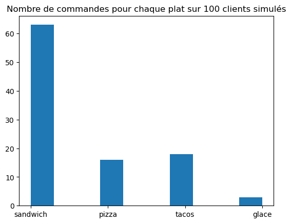

```python
plt.hist(commandes)  #dessiner l'histogramme des commandes
plt.title('Nombre de commandes pour chaque plat sur 100 clients simulés')
plt.show()
```

#### Calcul des probabilités de chaque plat à partir de la simulation

```python
#Calculer le nombre d'occurence de chaque plat sur les 100 commandes simulées
List_plats, occurences = np.unique(commandes, return_counts=True)
print('plats=', List_plats)
print('occurences=', occurences)

for i, plat in enumerate(List_plats):
    print("Le plat %s a été commandé %d fois/%d sa probabilité=%.4f"%(plat, occurences[i], n, occurences[i]/n))
```

```
plats= ['glace' 'pizza' 'sandwich' 'tacos']
occurences= [ 3 16 63 18]
Le plat glace a été commandé 3 fois/100 sa probabilité=0.0300
Le plat pizza a été commandé 16 fois/100 sa probabilité=0.1600
Le plat sandwich a été commandé 63 fois/100 sa probabilité=0.6300
Le plat tacos a été commandé 18 fois/100 sa probabilité=0.1800
```

On remarque que les probabilités estimées de la simulation sont proches des probabilités qu'on a spécifié au départ, elles peuvent être encore plus proches si on augmente la taille du tirage (ex: 1000 ou 10000 au lieu de 100)

#### Simuler avec une boucle 1 commande à la fois

```python
for i in range(10): #simuler 10 commandes
    commande=rd.choice(plats, p=prob) #choisir 1 seul plat
    print('Client %d a commandé: %s'%(i, commande))
```

```
Client 0 a commandé: sandwich
Client 1 a commandé: sandwich
Client 2 a commandé: sandwich
Client 3 a commandé: tacos
Client 4 a commandé: pizza
Client 5 a commandé: pizza
Client 6 a commandé: pizza
Client 7 a commandé: tacos
Client 8 a commandé: sandwich
Client 9 a commandé: tacos
```

### Exemple 2: Simulation de l'arrivée d'un évènement

Dans un commerce ouvert de 9h à 17h on a observé l'arrivée de 96 clients, simulez l'arrivée des clients par minute pour une durée de 2 heures.

#### Solution:

De 9h à 17h = 8 heures  
La moyenne d'arrivée par minute = 96 clients / (8 heures x 60 minutes) = 0.2 clients / minute

```python
#Arrivée d'un client si retour=True,  p: probabilité d'arrivée
def arrivee_client(p):
    return rd.choice([True, False],p=[p, 1-p])

#fonction de simulation, p: probabilité d'arrivée, duree: durée de la simulation
def simulation_clients(p, duree):
    id_client=0  #numéro du client
    for t in range(duree):
        if arrivee_client(p):
            print("Minute %d: arrivée du client%d"%(t, id_client))
            id_client=id_client+1



############## Appel de la fonction simulation ##############
p_arrive=0.2   # la probabilité d'arrivée d'un client par minute
duree=2*60     # durée de la simulation: 2heures x 60minutes
simulation_clients(p_arrive, duree)
```

```
Minute 0: arrivée du client0
Minute 2: arrivée du client1
Minute 5: arrivée du client2
Minute 9: arrivée du client3
Minute 14: arrivée du client4
Minute 17: arrivée du client5
Minute 22: arrivée du client6
Minute 25: arrivée du client7
Minute 41: arrivée du client8
Minute 43: arrivée du client9
Minute 51: arrivée du client10
Minute 64: arrivée du client11
Minute 66: arrivée du client12
Minute 70: arrivée du client13
Minute 73: arrivée du client14
Minute 75: arrivée du client15
Minute 77: arrivée du client16
Minute 78: arrivée du client17
Minute 81: arrivée du client18
Minute 83: arrivée du client19
Minute 87: arrivée du client20
Minute 94: arrivée du client21
Minute 98: arrivée du client22
Minute 99: arrivée du client23
Minute 104: arrivée du client24
Minute 105: arrivée du client25
Minute 108: arrivée du client26
Minute 110: arrivée du client27
Minute 111: arrivée du client28
Minute 118: arrivée du client29
```

### Exemple 3: Simulation de la durée d'un évènement

Sur la boite d'une ampoule il est inscrit: durée de vie moyenne = 30 jours. Un client achète 10 ampoules, simulez la durée de vie de chaque ampoule.

#### Solution:

Durée de vie moyenne d'une ampoule = 30 jours => la probabilité qu'une ampoule grille par jour = 1/30

```python
#Une ampoule grille si retour=True
def ampoule_grille(p):
    return rd.choice([True, False],p=[p, 1-p])


def simulation_ampoule(p, nb=1):
    id_ampoule=0 #numéro de l'ampoule à simuler
    jour=0       #compteur de jours
    installation=[0]  #liste pour stocker le jour d'installation de chaque ampoule
    while id_ampoule<=nb:
        if ampoule_grille(p):
            print("Jour %d: L'ampoule %d/%d a grillé, durée de vie: %d jours"
                  %(jour, id_ampoule+1, nb, jour-installation[id_ampoule]))
            id_ampoule=id_ampoule+1
            installation.append(jour)

        jour=jour+1


############## Appel de la fonction simulation ##############
nb_ampoules=10  #nombre d'ampoules à simuler
p_grille=1/30   #la probabilité qu'une ampoule grille par jour
simulation_ampoule(p_grille, nb=nb_ampoules)
```

```
Jour 20: L'ampoule 1/10 a grillé, durée de vie: 20 jours
Jour 28: L'ampoule 2/10 a grillé, durée de vie: 8 jours
Jour 51: L'ampoule 3/10 a grillé, durée de vie: 23 jours
Jour 98: L'ampoule 4/10 a grillé, durée de vie: 47 jours
Jour 110: L'ampoule 5/10 a grillé, durée de vie: 12 jours
Jour 137: L'ampoule 6/10 a grillé, durée de vie: 27 jours
Jour 183: L'ampoule 7/10 a grillé, durée de vie: 46 jours
Jour 199: L'ampoule 8/10 a grillé, durée de vie: 16 jours
Jour 204: L'ampoule 9/10 a grillé, durée de vie: 5 jours
Jour 285: L'ampoule 10/10 a grillé, durée de vie: 81 jours
Jour 301: L'ampoule 11/10 a grillé, durée de vie: 16 jours
```

# Partie Exercices

## Exercice 1

Soit 2 listes, une liste d'étudiants et une liste de sujets. Ecrire un programme qui permet d'affecter aléatoirement à chaque étudiant un sujet unique (différent des autres) parmi la liste des sujets en créant une liste de dictionnaires où chaque dictionnaire contient 2 champs : "nom" le nom d'un étudiant, "sujet" le sujet affecté à l'étudiant.

```python
etudiants=["Houssem","Amir","Yacine","Riyad","Mohamed","Youcef"]
sujets=["Sujet1","Sujet2","Sujet3","Sujet4","Sujet5","Sujet6","Sujet7","Sujet8"]
```

Exemple de sortie:

[{'nom': 'Houssem', 'sujet': 'Sujet6'}, {'nom': 'Amir', 'sujet': 'Sujet4'}, {'nom': 'Yacine', 'sujet': 'Sujet1'}, {'nom': 'Riyad', 'sujet': 'Sujet5'}, {'nom': 'Mohamed', 'sujet': 'Sujet2'}, {'nom': 'Youcef', 'sujet': 'Sujet7'}]

## Exercice 2

Q1. Ecrire un programme qui permet de simuler un jeux de pierre-papier-ciseaux entre vous et le PC et d'afficher le score après 5 parties (nombre de parties gagnées, perdues et nulles).

Q2. Que devient le programme si on veut que le PC ait 2 fois plus de chances de choisir pierre que papier et ciseaux.

## Exercice 3

Soit un restaurant :

1. Le restaurant dispose de 20 chaises pour ses clients.
2. D'après des statistiques sur 100 heures le restaurant a reçu 900 clients.
3. Le restaurant dispose d'un seul cuisinier qui traite chaque commande dans une durée moyenne de 10 minutes.
4. Le temps moyen pour qu'un client consomme sa commande est de 10 minutes.
5. Chaque client occupe une chaise à partir du moment de son arrivée + le temps d’attente de sa commande + le temps de consommation de sa commande, un client est rejeté si toutes les chaises sont occupées lors de son arrivée.

Q1. Ecrire un programme qui permet de :

1. Simuler par minute l’arrivée des clients au restaurant, stockez dans une liste le moment (minute) d’arrivée de chaque client.
2. Vérifiez s'il y a une chaise vide pour chaque client qui arrive, si oui, incrémentez le nombre de chaises occupées puis mettre en file d’attente la commande du client pour être traitée par le cuisinier, sinon s'il n'y a pas de chaise libre le client est rejeté.
3. Simulez dans le même programme la durée de traitement de chaque commande de la file d’attente qui se fait par le cuisinier par la politique premier arrivé premier servi, stockez dans une liste le moment de fin de traitement de chaque commande.
4. Simulez dans le même programme la durée de consommation de chaque client lorsque sa commande est servie, puis décrémentez le nombre de chaises occupées afin de libérer une chaise.

Q2. Faites une simulation sur 100 heures puis estimez :

1. Le nombre total de clients reçus
2. Le nombre de clients rejetés
3. Le temps moyen que passe un client à attendre sa commande

Que pensez vous de ces chiffres ?

Q3.

1. Si on augmente la capacité du restaurant à 40 chaises, peut-on améliorer les métriques calculées en Q2? (testez par une simulation sur 100 heures)
2. En ajoutant un 2ième cuisinier le temps moyen de traitement d'une commande passe à 5 minutes, est-ce que cette solution permet d'améliorer les métriques calculées en Q2 ? (testez par une simulation sur 100 heures)